# AlphaSimR: Deploying genomic selection

Marcio Resende, professor[^1]

Marco Antonio Peixoto, Post doc[^2]

## Deploying genomic selection

In this vignette, we will present how to use **AlphaSimR** objects to deploy genomic selection (GS). In addition, we will show how to use BGLR package Pérez-Rodrı́guez and Los Campos (2022) for doing the predictions.

Genomic selection is a method that leverages both phenotype and genome data from historical individuals to develop a predictive model. This model is then applied to new individuals, utilizing their genome data alongside the prediction model to forecast their phenotype performance. The foundation of this predictive model lies in the inferred associations between variations in phenotypes and the corresponding variations along the genome. These associations are calculated for numerous positions in the genome, commonly referred to as genomic markers. The prevailing choice for such markers is often bi-allelic Single Nucleotide Polymorphisms (SNPs), a type of genetic variation that **AlphaSimR** emulates. Once these associations between phenotype and genome are established, it becomes possible to predict the performance of any individual genotyped for the selected set of SNP markers.

## One trait with additive effect

The first implementation will use one additive trait. Let’s create the founder genome and also a base population and assume the trait characteristics. In addition to the argument that we have been describing, we need to use the function `addSnpChip` to add the SNPs for each individual.

```r
library(AlphaSimR)
```

```r
# Founder haplotypes
founderPop = runMacs(nInd=1000, nChr=10, segSites=600)

# trait parameters
SP = SimParam$
  new(founderPop)$
  addTraitA(100)$
  addSnpChip(500)$ # Number of SNPs per pair of chromosome
  setVarE(h2=0.4)

# Split the founders into two population
pop1 = newPop(founderPop[1:500])
pop2 = newPop(founderPop[501:1000])

#SNPs
SNPop = pullSnpGeno(pop1)

SNPop[1:10,1:10]
```

```
##    1_1 1_2 1_4 1_5 1_6 1_7 1_9 1_10 1_11 1_12
## 1    1   1   1   1   1   2   1    0    0    2
## 2    0   2   0   2   0   2   1    0    1    2
## 3    2   0   2   0   2   2   2    0    0    2
## 4    2   0   2   0   2   2   2    0    0    1
## 5    1   1   1   1   1   2   1    0    1    2
## 6    1   1   1   1   1   2   1    0    1    2
## 7    1   1   1   1   1   2   1    0    0    2
## 8    1   1   1   1   1   1   0    0    1    2
## 9    1   1   1   1   1   2   1    0    1    1
## 10   1   1   1   1   1   2   1    0    1    2
```

### New population from crosses and training the model

Now, we can create a large F1 population derived from the initial individuals and fit a genomic selection model using the function `RRBLUP()` from **AlphaSimR**. We may use the phenotypes assumed out of `setPheno()` function and, together with the marker’s information, create a model that will give us the marker’s effects, as follows:

```r
# Create a third population derived from the first populations
pop3 = randCross(pop1, nCrosses=1000)
pop3 = setPheno(pop3, h2 = 0.6)

# Train a GS model using the first population
gsModel = RRBLUP(pop1, use = 'pheno') #RRBLUP
```

### Using markers effect to predict the values

Now that we have a calibration, we can deploy genomic selection by using the marker effects to predict, together with the genotypes of the target population, the estimated breeding value of the individuals.

```r
# Set EBVs for all populations using the GS model
pop1 = setEBV(pop1, gsModel)
pop2 = setEBV(pop2, gsModel)
pop3 = setEBV(pop3, gsModel)
```

### Measuring the correlation with the genetic value (parametric value of the trait)

We can measure how good was the prediction by comparing the actual true genetic value (gv) with the prediction (ebv) for each individual.

```r
# Measure prediction accuracy
cor(gv(pop1), ebv(pop1))
```

```
##        est_GV_Trait1
## Trait1      0.684094
```

```r
cor(gv(pop2), ebv(pop2))
```

```
##        est_GV_Trait1
## Trait1     0.5155265
```

```r
cor(gv(pop3), ebv(pop3))
```

```
##        est_GV_Trait1
## Trait1     0.5663513
```

## One trait with additive/dominance effect

So, we can implement the same pipeline as before but accounting for dominance effects. In this case, we may use the function `RRBLUP_D` from *AlphaSimR*.

```r
rm(list=ls())
library(AlphaSimR)

# Base genome
founderPop = runMacs(nInd=1000, nChr=10, segSites=600)

# Trait
SP = SimParam$
  new(founderPop)$
  addTraitAD(100,
             meanDD = 0.5,
             varDD = 0.2)$
  addSnpChip(500)$
  setVarE(h2=0.4)

# Split the founders into two population
pop1 = newPop(founderPop[1:500])
pop2 = newPop(founderPop[501:1000])
```

### New population from crosses and training the model

We may implement a model with additive and a model with additive and dominance effects in order to compare the implementations.

```r
# Create a third population derived from the first
pop3 = randCross(pop1, nCrosses=1000)

# Train a GS model using the first population
gsModel = RRBLUP(pop1) #RRBLUP

gsModelD = RRBLUP_D(pop1) ##RRBLUP with both, A+D
```

### Using markers effect to predict the values

Now we can deploy the model in the same way that we did before and use both models in the same three populations.

```r
# Set EBVs for all populations using the additive GS model
pop1 = setEBV(pop1, gsModel)
pop2 = setEBV(pop2, gsModel)
pop3 = setEBV(pop3, gsModel)

# Set EBVs for all populations using additive and dom the GS model
popD1 = setEBV(pop1, gsModelD)
popD2 = setEBV(pop2, gsModelD)
popD3 = setEBV(pop3, gsModelD)
```

### Measuring the correlation with the genetic value (parametric value of the trait)

Measuring the accuracies to see how was the impact of the dominance effect on the model.

```r
# Measure prediction accuracy
Pop1A = cor(gv(pop1), ebv(pop1))
Pop2A = cor(gv(pop2), ebv(pop2))
Pop3A = cor(gv(pop3), ebv(pop3))

# Measure prediction accuracy
Pop1AD = cor(gv(pop1), ebv(popD1))
Pop2AD = cor(gv(pop2), ebv(popD2))
Pop3AD = cor(gv(pop3), ebv(popD3))

df = data.frame(Pop = c('Pop1', 'Pop2', 'Pop3'),
                AModel = c(Pop1A, Pop2A, Pop3A),
                ADModel = c(Pop1AD, Pop2AD, Pop3AD))

df
```

```
##    Pop    AModel   ADModel
## 1 Pop1 0.7349608 0.7644090
## 2 Pop2 0.4512380 0.5456612
## 3 Pop3 0.5522422 0.6086121
```

## General combining ability model

**AlphaSimR** also gives us the possibility to calculate the general combining ability using genomic information.

```r
rm(list=ls())
library(AlphaSimR)

# Founder genome
founderPop = runMacs(nInd=102, nChr=10, segSites=600)

# Traits
SP = SimParam$
  new(founderPop)$
  addTraitAD(100,
             meanDD = 0.5,
             varDD = 0.2)$
  addSnpChip(500)$
  setVarE(h2=0.4)

# Split the founders into two population
lines = newPop(founderPop[1:100])
tester = newPop(founderPop[101:102])
```

Creating Doubled haploids (DHs)

```r
# Creating DHs and testers from the founder
DHs = makeDH(lines, 2)
TestDH = makeDH(tester, 1)

# Create the hybrid crosses
Hybrid = hybridCross(DHs, TestDH, crossPlan = "testcross")
Hybrid = setPheno(Hybrid)

# Genomic model for GCA
gsModel_GCA = RRBLUP_GCA(Hybrid)

# Model deployment
GCA_Male = setEBV(Hybrid, gsModel_GCA, value = 'male', simParam=SP)

GCA_Female = setEBV(Hybrid, gsModel_GCA, value = 'female', simParam=SP)
```

## Specific combining ability model

```r
rm(list=ls())
library(AlphaSimR)

# founder genome
founderPop = runMacs(nInd=102, nChr=10, segSites=600)

SP = SimParam$
  new(founderPop)$
  addTraitAD(100,
             meanDD = 0.5,
             varDD = 0.2)$
  addSnpChip(500)$
  setVarE(h2=0.4)

# Split the founders into two populations (distinct groups)
lines = newPop(founderPop[1:100])
tester = newPop(founderPop[101:102])
```

Creating DHs

```r
# Creating DHs and testers from the founder
DHs = makeDH(lines, 2)
TestDH = makeDH(tester, 1)

# Create the hybrid crosses
Hybrid = hybridCross(DHs, TestDH, crossPlan = "testcross")
Hybrid = setPheno(Hybrid)

# Genomic model for GCA
gsModel_SCA = RRBLUP_SCA(Hybrid)

# Model deployment
SCA_pop = setEBV(Hybrid, gsModel_SCA, value = 'gv', simParam=SP)
```

## Fixed effects on the population

We can also use a fixed effect in the model. The fixed effects get treated as a categorical variable and are used to construct a sum-to-zero design matrix. When we have years and locations, you want a unique fixed effect for each year by location combination.

Let’s create a founder genome and a population out of it.

```r
rm(list=ls())
library(AlphaSimR)

# founder genome
founderPop = runMacs(nInd=100, nChr=10, segSites=600)

SP = SimParam$
  new(founderPop)$
  addTraitAD(100,
             meanDD = 0.5,
             varDD = 0.2)$
  addSnpChip(500)$
  setVarE(h2=0.4)

# Split the founders into two populations (distinct groups)
pop = newPop(founderPop[1:100])
```

Population and output.

```r
# Generate populations for 4 locations - environments
loc1 = setPheno(pop)
loc2 = setPheno(pop)
loc3 = setPheno(pop)
loc4 = setPheno(pop)

# Combine locations into a training population
trainPop = c(loc1, loc2, loc3, loc4)

# Run GS model
gsModel1 = RRBLUP(trainPop)

# Set EBV
pop = setEBV(pop, gsModel1)

# Measure accuracy
AccNofix = cor(gv(pop), ebv(pop))

# Generate populations for 4 locations - environments
loc1 = setPheno(pop, fixEff=1)
loc2 = setPheno(pop, fixEff=2)
loc3 = setPheno(pop, fixEff=3)
loc4 = setPheno(pop, fixEff=4)

# Combine locations into a training population
trainPop = c(loc1, loc2, loc3, loc4)

# Run GS model
gsModel2 = RRBLUP(trainPop)

# Set EBV
pop = setEBV(pop, gsModel2)

# Measure accuracy
AccFix = cor(gv(pop), ebv(pop))

# Comparison

AccNofix
```

```
##        est_GV_Trait1
## Trait1       0.88759
```

```r
AccFix
```

```
##        est_GV_Trait1
## Trait1     0.9201086
```

## Multi-trait information into the prediction

In the same way that we predict estimated breeding values for one trait, we can deploy it for more than one trait as well.

For such, we will create a base genome and implement two traits for later prediction via genomic selection.

```r
rm(list=ls())
library(AlphaSimR)

# founder genome
founderPop = runMacs(nInd=200, nChr=10, segSites=600)

# Traits
SP = SimParam$
  new(founderPop)$
  addTraitAD(100,
             mean = c(10,100),
             var = c(5, 50),
             meanDD = c(0.5, 0.2),
             varDD = c(0.2, 0.1))$
  addSnpChip(500)$
  setVarE(h2=c(0.4, 0.8))

# Split the founders into two populations (distinct groups)
pop1 = newPop(founderPop[1:100])
pop2 = newPop(founderPop[101:200])
```

Several traits in the model

```r
# Create a third population derived from the first
F1Pop = randCross(pop1, nCrosses=1000)
F1Pop = setPheno(F1Pop, h2 = 0.4)

# Train a GS model using the first population
gsModel = RRBLUP(F1Pop, trait = c(1,2)) #RRBLUP

# Set EBVs for all populations using the GS model
pop1 = setEBV(pop1, gsModel)
pop2 = setEBV(pop2, gsModel)
F1Pop = setEBV(F1Pop, gsModel)
```

Measuring the correlation with the genetic value (parametric value of the trait)

```r
# Measure prediction accuracy
Pop1A = diag(cor(gv(pop1), ebv(pop1)))
Pop2A = diag(cor(gv(pop2), ebv(pop2)))
Pop3A = diag(cor(gv(F1Pop), ebv(F1Pop)))

df = data.frame(Pop = c('Pop1', 'Pop2', 'Pop3'),
                Trait1 = c(Pop1A[1], Pop2A[1], Pop3A[1]),
                Trait2 = c(Pop1A[2], Pop2A[2], Pop3A[2]))

df
```

```
##    Pop    Trait1    Trait2
## 1 Pop1 0.8263392 0.8308155
## 2 Pop2 0.4988778 0.5561157
## 3 Pop3 0.8094863 0.7863399
```

## Using another package to do predictions in the GS models

### Single trait

```r
rm(list=ls())

# Founder genome
founderGen = runMacs(nInd=100, nChr=10, segSites=600)

# Trait characteristics
SP = SimParam$
  new(founderGen)$
  addTraitAD(100,
             mean = 10,
             var = 2)$
  addSnpChip(100)$
  setVarE(h2=0.5)

# Create the individuals
pop = newPop(founderGen[1:100])

# Create a third population derived from the first
F1Pop = randCross(pop, nCrosses=200)
F1Pop = setPheno(F1Pop, h2 = 0.4)
```

### Using BGLR to deploy Genomic selection

We can use the information from the individuals to fit the model in BGLR. So, the first step will be to get that information from the population. We may get the phenotypic values for the individuals and the SNP data and create a relationship Matrix out of it.

```r
require(BGLR)
require(AGHmatrix)
# 1. Pulling data from AlphaSimR code
y = data.frame(Trait_1 = pheno(F1Pop)) # Phenotypic data
Markers = pullSnpGeno(F1Pop) #Access SNP genotype data
rownames(Markers) = F1Pop@id

# 2. Creating the G Matrix
G = Gmatrix(Markers)
```

[output not shown]

```r
# 3. Genomic model - Individuals effects
# Model - trait 1
fm_t1 = BGLR(y = y[,1],
             ETA=list(A = list(K=G, model="RKHS")),
             nIter = 300,
             burnIn = 30,
             thin = 5,
             saveAt = 'STM_',
             verbose = FALSE)


# 4. Saving it back to the population
F1Pop@ebv = as.matrix(fm_t1$yHat)

# 5. Selections using ebv
F1Sel = selectInd(F1Pop, 25, use = 'ebv')
```

### Multi-trait implementation using BGLR

The same implementation could be done with the information of more than one trait at a time. So, we will do the same implementation mentioned, but using two traits, as follows:

```r
rm(list=ls())
library(AlphaSimR)

# founder genome
founderPop = runMacs(nInd=100, nChr=10, segSites=600)

# Trait characteristics
SP = SimParam$
  new(founderPop)$
  addTraitAD(100,
             mean = c(10,100),
             var = c(2,10))$
  addSnpChip(100)$
  setVarE(h2=c(0.5,0.2))

# Creating the base population
pop = newPop(founderPop[1:100])

# Create a third population derived from the first
F1Pop = randCross(pop, nCrosses=200)
F1Pop = setPheno(F1Pop, h2 = 0.4)
```

Implementing the *Spikeslab* from BGLR using the `Multitrait` function. It will return the SNP effects for both traits.

```r
require(BGLR)

# 1. Pulling data from AlphaSimR code
Y = data.frame(Trait_1 = pheno(F1Pop))# Phenotypic data

Markers = pullSnpGeno(F1Pop) #Access SNP genotype data
rownames(Markers) = F1Pop@id

# 2. Genomic model - SNP effects model
fmSM<-Multitrait(y = as.matrix(Y),
                 ETA = list(A = list(X=Markers, model="SpikeSlab", saveEffects=TRUE)),
                 nIter = 300,
                 burnIn = 30,
                 verbose=FALSE)
```

[output not shown]

[output not shown]

[output not shown]

[output not shown]

[output not shown]

[output not shown]

[output not shown]

[output not shown]

[output not shown]

[output not shown]

[output not shown]

[output not shown]

[output not shown]

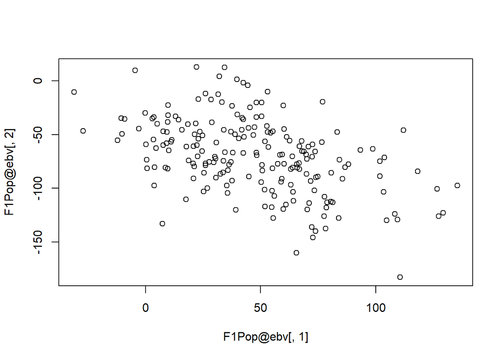

```r
# 3. Saving
addEff = as.matrix(cbind(fmSM$ETA[[1]]$b))

# 4. BackSolving to ebvs
F1Pop@ebv = as.matrix(Markers %*% scale(addEff))
plot(F1Pop@ebv[,1], F1Pop@ebv[,2])
```

```r
# 5. Selections
F1Sel = selectInd(F1Pop, 25, traits = c(1,2), use = 'ebv')
```

## References

Pérez, Paulino, and Gustavo de Los Campos. 2014. “Genome-Wide Regression and Prediction with the BGLR Statistical Package.” *Genetics* 198 (2): 483–95.

Pérez-Rodrı́guez, Paulino, and Gustavo de Los Campos. 2022. “Multitrait Bayesian Shrinkage and Variable Selection Models with the BGLR-r Package.” *Genetics* 222 (1): iyac112.

[^1]: University of Florida, mresende@ufl.edu
[^2]: University of Florida, deamorimpeixotom@ufl.edu